# Determine Workout Class

Justin Pizzino

10/13/2019

## 1. Overview

One thing that people regularly do is quantify how much of a particular activity they do, but they rarely quantify how well they do it. The goal of this project will be to use data from accelerometers on the belt, forearm, arm, and dumbell of 6 participants, to predict the manner in which they did the exercise.

## 2. Load Libraries

```r
library(data.table)
library(caret)
library(randomForest)
library(rpart)
library(rattle)
```

```r
library(corrplot)
```

## 3. Load and clean data. By handling the NA’s upfront we are speeding up our research. Any missing data will be convered to NA’s. Then we will remove the columns we don’t need for this effort, ones with out valuable data.

```r
trainDL<-read.csv("https://d396qusza40orc.cloudfront.net/predmachlearn/pml-training.csv", na.strings=c("NA","#DIV/0!",""))
testDL<-read.csv("https://d396qusza40orc.cloudfront.net/predmachlearn/pml-testing.csv", na.strings=c("NA","#DIV/0!",""))

keep <- names(trainDL[,colSums(is.na(trainDL)) == 0])[8:59]
trainDL <- trainDL[,c(keep,"classe")]
testDL <- testDL[,c(keep,"problem_id")]
```

## 4. Create training and test setup from training data, using 60%.

```r
training<-createDataPartition(trainDL$classe, p=0.6, list=FALSE)
myTrain<-trainDL[training, ]
myTest<-trainDL[-training, ]
```

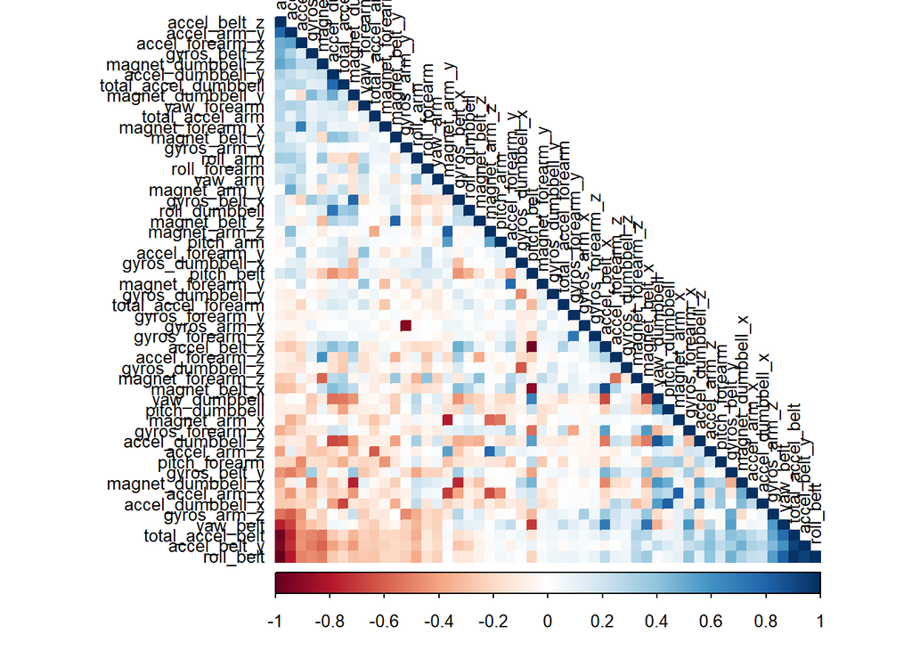

```r
myCor <- cor(myTrain[, -53])
corrplot(myCor, order = "FPC", method = "color", type = "lower",
         tl.cex = 0.8, tl.col = rgb(0, 0, 0))
```

## 6. The first model I chose is random forest as they work well with factor results. I also set the sead for repeatable results.

```r
set.seed(4564)
modRF<-randomForest(classe ~., data=myTrain, ntree=1500)
```

### 6.1 Let’s review the out of sample accuracy of the random forest: 99%

```r
predRF<-predict(modRF, myTest, type="class")
confusionMatrix(predRF,myTest$classe)
```

```
## Confusion Matrix and Statistics
##
##           Reference
## Prediction    A    B    C    D    E
##          A 2228   11    0    0    0
##          B    3 1502   10    0    0
##          C    0    5 1356   18    1
##          D    0    0    2 1268   12
##          E    1    0    0    0 1429
##
## Overall Statistics
##
##                Accuracy : 0.992
##                  95% CI : (0.9897, 0.9938)
##     No Information Rate : 0.2845
##     P-Value [Acc > NIR] : < 2.2e-16
##
##                   Kappa : 0.9898
##
##  Mcnemar's Test P-Value : NA
##
## Statistics by Class:
##
##                      Class: A Class: B Class: C Class: D Class: E
## Sensitivity            0.9982   0.9895   0.9912   0.9860   0.9910
## Specificity            0.9980   0.9979   0.9963   0.9979   0.9998
## Pos Pred Value         0.9951   0.9914   0.9826   0.9891   0.9993
## Neg Pred Value         0.9993   0.9975   0.9981   0.9973   0.9980
## Prevalence             0.2845   0.1935   0.1744   0.1639   0.1838
## Detection Rate         0.2840   0.1914   0.1728   0.1616   0.1821
## Detection Prevalence   0.2854   0.1931   0.1759   0.1634   0.1823
## Balanced Accuracy      0.9981   0.9937   0.9938   0.9919   0.9954
```

## 7. Next I boosted the results to see if I would get a more accurate prediction.

```r
set.seed(4564)
control<-trainControl(method = "repeatedcv", number = 5, repeats =1)
modGBM<-train(classe~.,data=myTrain,method="gbm",verbose=FALSE, trControl=control)
```

```r
predGBM<-predict(modGBM,newdata=myTest)
confusionMatrix(predGBM, myTest$classe)
```

```
## Confusion Matrix and Statistics
##
##           Reference
## Prediction    A    B    C    D    E
##          A 2196   55    0    2    3
##          B   26 1422   48   13   24
##          C    4   38 1297   58   13
##          D    4    2   21 1207   26
##          E    2    1    2    6 1376
##
## Overall Statistics
##
##                Accuracy : 0.9556
##                  95% CI : (0.9509, 0.9601)
##     No Information Rate : 0.2845
##     P-Value [Acc > NIR] : < 2.2e-16
##
##                   Kappa : 0.9439
##
##  Mcnemar's Test P-Value : 1.015e-13
##
## Statistics by Class:
##
##                      Class: A Class: B Class: C Class: D Class: E
## Sensitivity            0.9839   0.9368   0.9481   0.9386   0.9542
## Specificity            0.9893   0.9825   0.9826   0.9919   0.9983
## Pos Pred Value         0.9734   0.9276   0.9199   0.9579   0.9921
## Neg Pred Value         0.9936   0.9848   0.9890   0.9880   0.9898
## Prevalence             0.2845   0.1935   0.1744   0.1639   0.1838
## Detection Rate         0.2799   0.1812   0.1653   0.1538   0.1754
## Detection Prevalence   0.2875   0.1954   0.1797   0.1606   0.1768
## Balanced Accuracy      0.9866   0.9596   0.9653   0.9652   0.9763
```

## 8. Based on this the random forest method appears to the the better method, and that will be used for the quiz.